# RStudio exercise 5: Dimensionality reduction techniques

## Introduction to the data

The data of this exercise originates from the United Nations Development Programme. Human development index (HDI) was created to emphasize that people and their capabilities should be the ultimate criteria for assessing the development of a country, not economic growth alone.

Original data can be found from: http://hdr.undp.org/en/content/human-development-index-hdi

Modified dataset includes 9 variables and 155 observations as follows:

| variable | description |
| --- | --- |
| country | Country name (name of the row) |
| gni_capita | Gross national income per capita |
| life_exp | Life expectancy at birth |
| edu_years | Expected years of schooling |
| mortality | Maternal mortality ratio |
| young_mom | Adolescent birth rate |
| women_parlament | Percentange of female representatives in parliament |
| edu_ratio | Ratio between females and males at least secondary education |
| labour_ratio | Ratio between females and males in the labour force |

### Summary of the data

```
## 'data.frame':    155 obs. of  8 variables:
##  $ gni_capita     : int  64992 42261 56431 44025 45435 43919 39568 52947 42155 32689 ...
##  $ life_exp       : num  81.6 82.4 83 80.2 81.6 80.9 80.9 79.1 82 81.8 ...
##  $ edu_years      : num  17.5 20.2 15.8 18.7 17.9 16.5 18.6 16.5 15.9 19.2 ...
##  $ mortality      : int  4 6 6 5 6 7 9 28 11 8 ...
##  $ young_mom      : num  7.8 12.1 1.9 5.1 6.2 3.8 8.2 31 14.5 25.3 ...
##  $ women_parlament: num  39.6 30.5 28.5 38 36.9 36.9 19.9 19.4 28.2 31.4 ...
##  $ edu_ratio      : num  1.007 0.997 0.983 0.989 0.969 ...
##  $ labour_ratio   : num  0.891 0.819 0.825 0.884 0.829 ...
```

All the variables are either numerical or integers. Two of the variables are ratios (*edu_ratio*, *labour_ratio*).

### Summary, distributions of the variables and the relationships between them

```
##    gni_capita        life_exp       edu_years       mortality
##  Min.   :   581   Min.   :49.00   Min.   : 5.40   Min.   :   1.0
##  1st Qu.:  4198   1st Qu.:66.30   1st Qu.:11.25   1st Qu.:  11.5
##  Median : 12040   Median :74.20   Median :13.50   Median :  49.0
##  Mean   : 17628   Mean   :71.65   Mean   :13.18   Mean   : 149.1
##  3rd Qu.: 24512   3rd Qu.:77.25   3rd Qu.:15.20   3rd Qu.: 190.0
##  Max.   :123124   Max.   :83.50   Max.   :20.20   Max.   :1100.0
##    young_mom      women_parlament   edu_ratio       labour_ratio
##  Min.   :  0.60   Min.   : 0.00   Min.   :0.1717   Min.   :0.1857
##  1st Qu.: 12.65   1st Qu.:12.40   1st Qu.:0.7264   1st Qu.:0.5984
##  Median : 33.60   Median :19.30   Median :0.9375   Median :0.7535
##  Mean   : 47.16   Mean   :20.91   Mean   :0.8529   Mean   :0.7074
##  3rd Qu.: 71.95   3rd Qu.:27.95   3rd Qu.:0.9968   3rd Qu.:0.8535
##  Max.   :204.80   Max.   :57.50   Max.   :1.4967   Max.   :1.0380
```

There is greate variation between numeric variables. Variable like Gross national income per capita (*gni_capita*) differs between 581$ (min) -123,124$ (max) and at the same time there is two variables (*edu_ratio*, *labour_ratio*) that are ratios and differs both sides of number 1. Life expectancy (*life_exp*) and expected years of schooling (*edu_years*) are in years and the max observation is under 100 years. The percentange of female representatives in parliament (*women_parlament*) is the only variable that is represented in percentange.

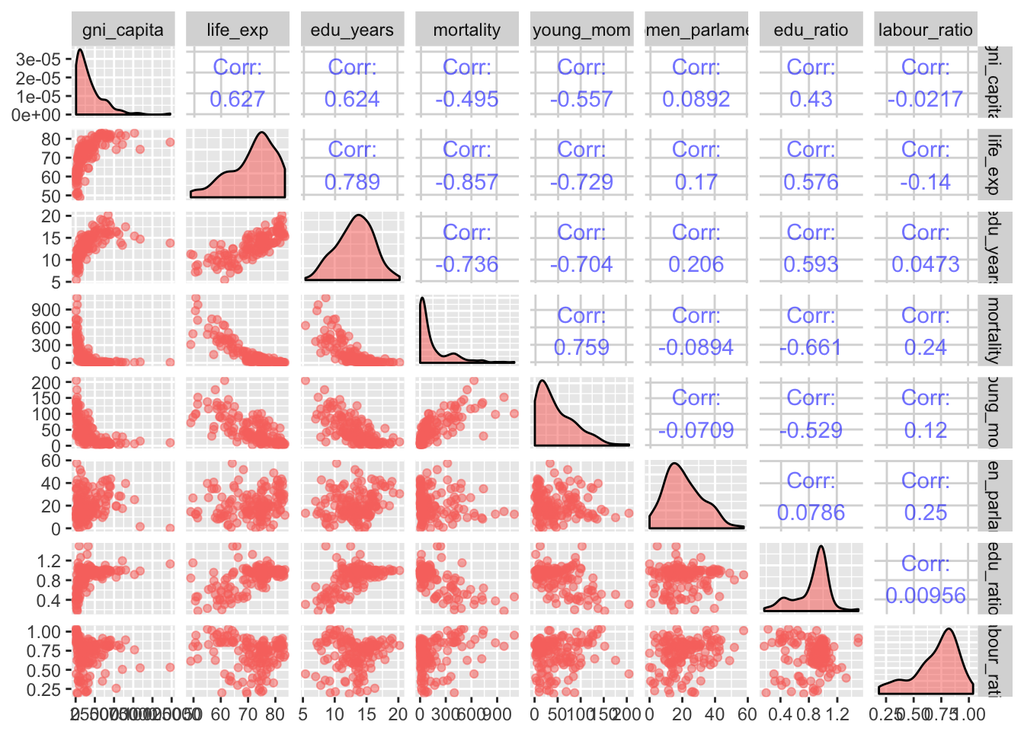

Maternal mortality (*mortality*) ratio correlates strongly (negatively) with life expectancy, excpected years of schooling and education ratio between females and males. Maternal mortality and adolescent birth rates appears to be connected too. One could make conclusion that in some countries uneducated females give birth at very young age and that leeds to high maternal mortality rate.

Gross income per capita appears to be connected to life expectancy and expected years in schooling. Is it so that educated labour force helps society to prosper in economic sense.

## Principal component analysis (PCA)

First we conduct PCA with unstandardized data

### PCA with unstandardized data

```
## Standard deviations:
## [1] 1.854416e+04 1.855219e+02 2.518701e+01 1.145441e+01 3.766241e+00
## [6] 1.565912e+00 1.912052e-01 1.591112e-01
##
## Rotation:
##                           PC1           PC2           PC3           PC4
## gni_capita      -9.999832e-01 -0.0057723054  5.156742e-04 -4.932889e-05
## life_exp        -2.815823e-04  0.0283150248 -1.294971e-02  6.752684e-02
## edu_years       -9.562910e-05  0.0075529759 -1.427664e-02  3.313505e-02
## mortality        5.655734e-03 -0.9916320120 -1.260302e-01  6.100534e-03
## young_mom        1.233961e-03 -0.1255502723  9.918113e-01 -5.301595e-03
## women_parlament -5.526460e-05  0.0032317269  7.398331e-03  9.971232e-01
## edu_ratio       -5.607472e-06  0.0006713951  3.412027e-05  2.736326e-04
## labour_ratio     2.331945e-07 -0.0002819357 -5.302884e-04  4.692578e-03
##                           PC5           PC6           PC7           PC8
## gni_capita      -0.0001135863  2.711698e-05  8.075191e-07 -1.176762e-06
## life_exp         0.9865644425  1.453515e-01 -5.380452e-03  2.281723e-03
## edu_years        0.1431180282 -9.882477e-01  3.826887e-02  7.776451e-03
## mortality        0.0266373214 -1.695203e-03 -1.355518e-04  8.371934e-04
## young_mom        0.0188618600 -1.273198e-02  8.641234e-05 -1.707885e-04
## women_parlament -0.0716401914  2.309896e-02  2.642548e-03  2.680113e-03
## edu_ratio       -0.0022935252 -2.180183e-02 -6.998623e-01  7.139410e-01
## labour_ratio     0.0022190154 -3.264423e-02 -7.132267e-01 -7.001533e-01
```

```
## Importance of components:
##                              PC1      PC2   PC3   PC4   PC5   PC6    PC7
## Standard deviation     1.854e+04 185.5219 25.19 11.45 3.766 1.566 0.1912
## Proportion of Variance 9.999e-01   0.0001  0.00  0.00 0.000 0.000 0.0000
## Cumulative Proportion  9.999e-01   1.0000  1.00  1.00 1.000 1.000 1.0000
##                           PC8
## Standard deviation     0.1591
## Proportion of Variance 0.0000
## Cumulative Proportion  1.0000
```

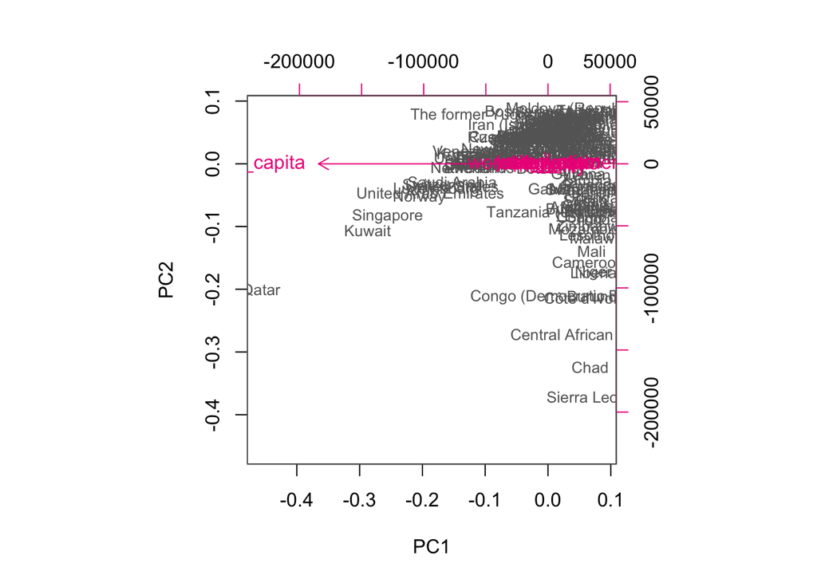

The plot doesn’t look good. A large variance of the gross income per capita variable makes it too important for the principal component analysis. The data need to be standardized.

### Summary of the standardized variables

```
##    gni_capita         life_exp         edu_years         mortality
##  Min.   :-0.9193   Min.   :-2.7188   Min.   :-2.7378   Min.   :-0.6992
##  1st Qu.:-0.7243   1st Qu.:-0.6425   1st Qu.:-0.6782   1st Qu.:-0.6496
##  Median :-0.3013   Median : 0.3056   Median : 0.1140   Median :-0.4726
##  Mean   : 0.0000   Mean   : 0.0000   Mean   : 0.0000   Mean   : 0.0000
##  3rd Qu.: 0.3712   3rd Qu.: 0.6717   3rd Qu.: 0.7126   3rd Qu.: 0.1932
##  Max.   : 5.6890   Max.   : 1.4218   Max.   : 2.4730   Max.   : 4.4899
##    young_mom       women_parlament     edu_ratio        labour_ratio
##  Min.   :-1.1325   Min.   :-1.8203   Min.   :-2.8189   Min.   :-2.6247
##  1st Qu.:-0.8394   1st Qu.:-0.7409   1st Qu.:-0.5233   1st Qu.:-0.5484
##  Median :-0.3298   Median :-0.1403   Median : 0.3503   Median : 0.2316
##  Mean   : 0.0000   Mean   : 0.0000   Mean   : 0.0000   Mean   : 0.0000
##  3rd Qu.: 0.6030   3rd Qu.: 0.6127   3rd Qu.: 0.5958   3rd Qu.: 0.7350
##  Max.   : 3.8344   Max.   : 3.1850   Max.   : 2.6646   Max.   : 1.6632
```

### PCA with standardized data

```
## Standard deviations:
## [1] 2.0708380 1.1397204 0.8750485 0.7788630 0.6619563 0.5363061 0.4589994
## [8] 0.3222406
##
## Rotation:
##                         PC1         PC2         PC3         PC4        PC5
## gni_capita      -0.35048295 -0.05060876  0.20168779 -0.72727675  0.4950306
## life_exp        -0.44372240  0.02530473 -0.10991305 -0.05834819 -0.1628935
## edu_years       -0.42766720 -0.13940571  0.07340270 -0.07020294 -0.1659678
## mortality        0.43697098 -0.14508727  0.12522539 -0.25170614  0.1800657
## young_mom        0.41126010 -0.07708468 -0.01968243  0.04986763  0.4672068
## women_parlament -0.08438558 -0.65136866 -0.72506309  0.01396293  0.1523699
## edu_ratio       -0.35664370 -0.03796058  0.24223089  0.62678110  0.5983585
## labour_ratio     0.05457785 -0.72432726  0.58428770  0.06199424 -0.2625067
##                         PC6         PC7         PC8
## gni_capita      -0.11120305 -0.13711838 -0.16961173
## life_exp         0.42242796 -0.43406432  0.62737008
## edu_years        0.38606919  0.77962966 -0.05415984
## mortality       -0.17370039  0.35380306  0.72193946
## young_mom        0.76056557 -0.06897064 -0.14335186
## women_parlament -0.13749772  0.00568387 -0.02306476
## edu_ratio       -0.17713316  0.05773644  0.16459453
## labour_ratio     0.03500707 -0.22729927 -0.07304568
```

```
## Importance of components:
##                           PC1    PC2     PC3     PC4     PC5     PC6
## Standard deviation     2.0708 1.1397 0.87505 0.77886 0.66196 0.53631
## Proportion of Variance 0.5361 0.1624 0.09571 0.07583 0.05477 0.03595
## Cumulative Proportion  0.5361 0.6984 0.79413 0.86996 0.92473 0.96069
##                            PC7     PC8
## Standard deviation     0.45900 0.32224
## Proportion of Variance 0.02634 0.01298
## Cumulative Proportion  0.98702 1.00000
```

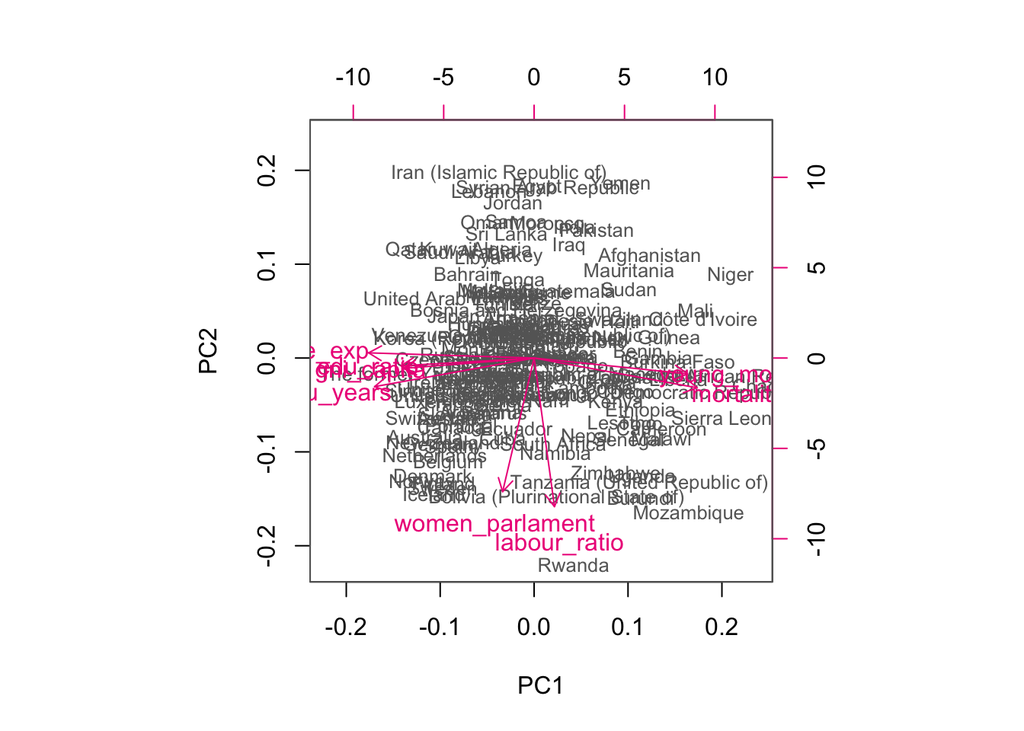

Biplots of the unstandardized and standardized data differ in many ways. Large variance of the *gni_capita* variable in unstandardized human data distorts the analysis and biplot. The importance of first component before standardation is almost ~100 %. When the data is scaled propely the impact of each variable is reasonable. Importance of the first component after standartation is ~54%.Also the biplot looks better when the mean of the observations is in the middle of the plot.

### Dimensions of the principal components

Variables *mortality* and *young_mom* are positively correlated to the first principal component (PC1). *Gni_capita*, *life_exp*, *edu_years* and *edu_ratio* also correlate but the correlation is negative. In the biplot arrows of the negatively correlating dimensions are against PC1 axis. Variables *women_parlament* and *labour_ratio* are not significant for PC1. Starndard deviations of standardized variables are similar. First principal component explains variance by ~53,6%.

Second principal component explains variance by ~16,2% and important variables are *women_parlament* and *labour_ratio*. Those variables correlate negatively to PC2.

## Multiple correspondece analysisi (MCA)

In this analysis we are using dataset *tea* from the FactoMineR package.

```
## [1] 300  36
```

```
## 'data.frame':    300 obs. of  36 variables:
##  $ breakfast       : Factor w/ 2 levels "breakfast","Not.breakfast": 1 1 2 2 1 2 1 2 1 1 ...
##  $ tea.time        : Factor w/ 2 levels "Not.tea time",..: 1 1 2 1 1 1 2 2 2 1 ...
##  $ evening         : Factor w/ 2 levels "evening","Not.evening": 2 2 1 2 1 2 2 1 2 1 ...
##  $ lunch           : Factor w/ 2 levels "lunch","Not.lunch": 2 2 2 2 2 2 2 2 2 2 ...
##  $ dinner          : Factor w/ 2 levels "dinner","Not.dinner": 2 2 1 1 2 1 2 2 2 2 ...
##  $ always          : Factor w/ 2 levels "always","Not.always": 2 2 2 2 1 2 2 2 2 2 ...
##  $ home            : Factor w/ 2 levels "home","Not.home": 1 1 1 1 1 1 1 1 1 1 ...
##  $ work            : Factor w/ 2 levels "Not.work","work": 1 1 2 1 1 1 1 1 1 1 ...
##  $ tearoom         : Factor w/ 2 levels "Not.tearoom",..: 1 1 1 1 1 1 1 1 1 2 ...
##  $ friends         : Factor w/ 2 levels "friends","Not.friends": 2 2 1 2 2 2 1 2 2 2 ...
##  $ resto           : Factor w/ 2 levels "Not.resto","resto": 1 1 2 1 1 1 1 1 1 1 ...
##  $ pub             : Factor w/ 2 levels "Not.pub","pub": 1 1 1 1 1 1 1 1 1 1 ...
##  $ Tea             : Factor w/ 3 levels "black","Earl Grey",..: 1 1 2 2 2 2 2 1 2 1 ...
##  $ How             : Factor w/ 4 levels "alone","lemon",..: 1 3 1 1 1 1 1 3 3 1 ...
```

[output cut: 22 more lines]

The tea dataset includes 300 observation and 36 variables. For the analysis we are using only certain columnns of the data.

```
##        home           work            friends       How      sex
##  home    :291   Not.work:213   friends    :196   alone:195   F:178
##  Not.home:  9   work    : 87   Not.friends:104   lemon: 33   M:122
##                                                  milk : 63
##                                                  other:  9
##         healthy           exciting          relaxing
##  healthy    :210   exciting   :116   No.relaxing:113
##  Not.healthy: 90   No.exciting:184   relaxing   :187
##
##
##            sophisticated           spirituality
##  Not.sophisticated: 85   Not.spirituality:206
##  sophisticated    :215   spirituality    : 94
##
##
```

```
## 'data.frame':    300 obs. of  10 variables:
##  $ home         : Factor w/ 2 levels "home","Not.home": 1 1 1 1 1 1 1 1 1 1 ...
##  $ work         : Factor w/ 2 levels "Not.work","work": 1 1 2 1 1 1 1 1 1 1 ...
##  $ friends      : Factor w/ 2 levels "friends","Not.friends": 2 2 1 2 2 2 1 2 2 2 ...
##  $ How          : Factor w/ 4 levels "alone","lemon",..: 1 3 1 1 1 1 1 3 3 1 ...
##  $ sex          : Factor w/ 2 levels "F","M": 2 1 1 2 2 2 2 1 2 2 ...
##  $ healthy      : Factor w/ 2 levels "healthy","Not.healthy": 1 1 1 1 2 1 1 1 2 1 ...
##  $ exciting     : Factor w/ 2 levels "exciting","No.exciting": 2 1 2 2 2 2 2 2 2 2 ...
##  $ relaxing     : Factor w/ 2 levels "No.relaxing",..: 1 1 2 2 2 2 2 2 2 2 ...
##  $ sophisticated: Factor w/ 2 levels "Not.sophisticated",..: 1 1 1 2 1 1 1 2 2 1 ...
##  $ spirituality : Factor w/ 2 levels "Not.spirituality",..: 1 1 1 2 2 1 1 1 1 1 ...
```

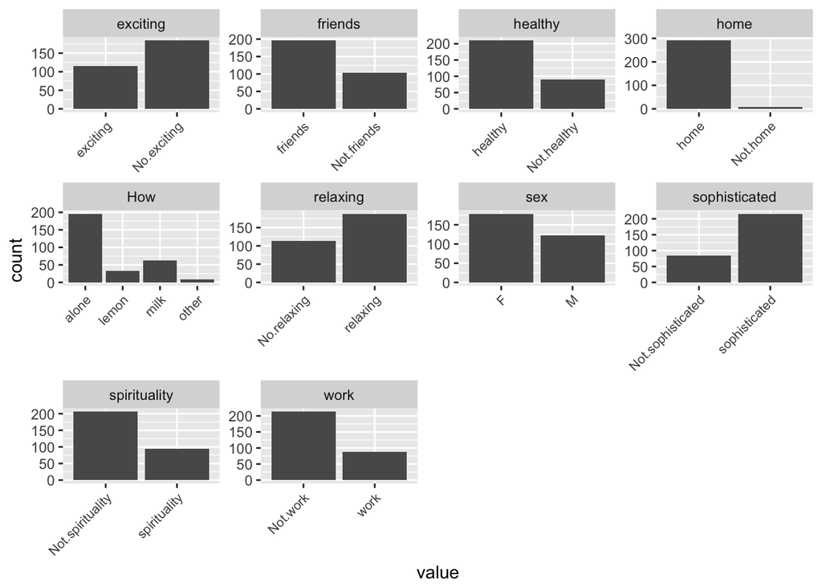

```r
mca <- MCA(tea_attitude, graph = FALSE)
summary(mca)
```

```
##
## Call:
## MCA(X = tea_attitude, graph = FALSE)
##
##
## Eigenvalues
##                        Dim.1   Dim.2   Dim.3   Dim.4   Dim.5   Dim.6
## Variance               0.147   0.134   0.118   0.115   0.106   0.102
## % of var.             12.236  11.141   9.809   9.620   8.803   8.519
## Cumulative % of var.  12.236  23.377  33.186  42.806  51.609  60.129
##                        Dim.7   Dim.8   Dim.9  Dim.10  Dim.11  Dim.12
## Variance               0.096   0.091   0.081   0.079   0.073   0.058
## % of var.              8.037   7.588   6.709   6.568   6.102   4.867
## Cumulative % of var.  68.165  75.754  82.463  89.031  95.133 100.000
##
## Individuals (the 10 first)
##                Dim.1    ctr   cos2    Dim.2    ctr   cos2    Dim.3    ctr
## 1           |  0.401  0.365  0.161 | -0.666  1.106  0.443 |  0.161  0.073
## 2           |  0.569  0.736  0.241 | -0.254  0.161  0.048 |  0.461  0.601
## 3           | -0.427  0.414  0.205 | -0.185  0.085  0.038 |  0.218  0.134
## 4           | -0.180  0.074  0.038 | -0.178  0.079  0.037 | -0.270  0.206
## 5           |  0.149  0.050  0.018 | -0.454  0.514  0.164 | -0.081  0.019
## 6           |  0.053  0.006  0.003 | -0.734  1.342  0.600 |  0.128  0.046
## 7           | -0.129  0.038  0.022 | -0.536  0.716  0.377 |  0.248  0.174
## 8           | -0.170  0.066  0.031 | -0.379  0.357  0.154 |  0.071  0.014
## 9           |  0.247  0.138  0.051 | -0.476  0.564  0.189 |  0.101  0.029
## 10          |  0.053  0.006  0.003 | -0.734  1.342  0.600 |  0.128  0.046
##               cos2
## 1            0.026 |
## 2            0.158 |
## 3            0.053 |
## 4            0.085 |
## 5            0.005 |
## 6            0.018 |
## 7            0.081 |
## 8            0.005 |
## 9            0.008 |
## 10           0.018 |
##
## Categories (the 10 first)
```

[output cut: 20 more lines]

```
## milk         -1.063 |   1.035  19.127   0.285   9.231 |
## other        -0.102 |   0.761   1.476   0.018   2.314 |
##
## Categorical variables (eta2)
##                 Dim.1 Dim.2 Dim.3
## home          | 0.127 0.038 0.098 |
## work          | 0.032 0.201 0.054 |
## friends       | 0.111 0.118 0.039 |
## How           | 0.128 0.190 0.554 |
## sex           | 0.135 0.021 0.091 |
## healthy       | 0.152 0.001 0.055 |
## exciting      | 0.283 0.319 0.001 |
## relaxing      | 0.417 0.014 0.003 |
## sophisticated | 0.034 0.184 0.273 |
## spirituality  | 0.051 0.251 0.009 |
```

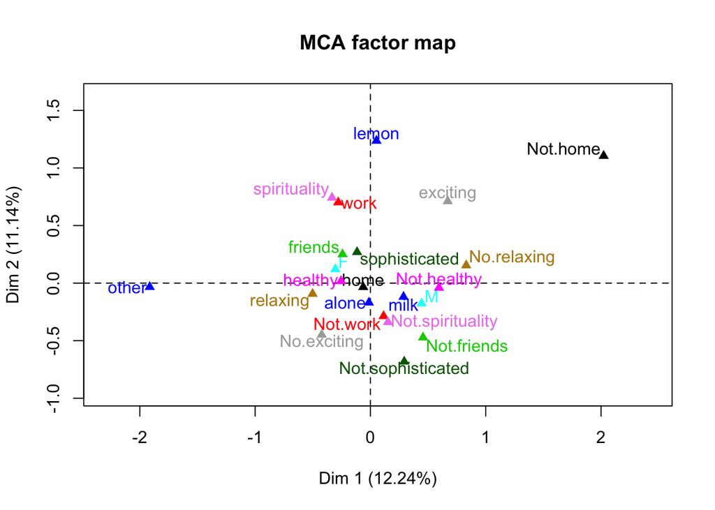

```r
plot(mca, invisible=c("ind"), habillage = "quali")
```

It seems that females experience tea as a drink that correlates with spirituality, sophistication and healthy. They seem to drink it with friends and they are using lemon more than males.

Males don’t drink their tea at work. They don’t think it’s healthy and they tend to drink it alone or at least not with friends. Males use milk more than females with tea.